# Small Area Estimation : Area Level Model

Paisan Leewattana

2026-03-18

*Small Area Estimation : Area Level Model EBLUP* *Fay-Harriot Model Estimate* : Amphor/District Level  
This presentation uses data from district-level surveys, combined with Auxiliary Data from Administrative data and Remote sensing data.  
1. Direct estimates ($\hat{y}_{i}^{dir}$) : survey district level.  
$\hat{y}_i^{dir} = y_i + e_i$ , $e_i$ = Sampling error $e_i \sim N(0, \sigma_e^2)$  
2. Auxiliary Data ($x_d$) : Administrative data , Remote Sensing Data Geospatial data …etc.  
3. Select X variable dont multicolinearlity : drop Variable VIF > 5  
4. EBLUP Model $y_{i}^{\prime}=x_{i}^{\prime}\beta+u_{i}$ , $u_d$ Random area effect $u_i \sim N(0, \sigma_u^2)$  
5. EBLUP FH Model Yi = xiB + ui + ei  
6. Shrinkage Factor (Weighting $\gamma_i$) $\hat{\theta}_i^{EB} = \gamma_i \hat{y}_i^{dir } + (1 - \gamma_i) \mathbf{x}_i^T \hat{\beta}$ , $\gamma_i = \frac{\sigma_u^2}{\sigma_u^2 + D_i}$  
7. Evaluation

```
 **Direct Estimates : Survey VS Small Area Estimates (SAE): Fay-Harriot Model**
```

# 1.Import Data Frame

#### Load Data Frame

Install Package and Library

Load data frame SES survey and Create Direct Estimate and weight and Sample size(n)

```r
df <- read_excel("ses2023.xlsx")
names(df) <- trimws(names(df))
df$adm2_pcode <- paste0(df$CWT, df$AMP)
df$adm2_pcode <- sprintf("TH%02d%02d",
                         as.numeric(df$CWT),
                         as.numeric(df$AMP))

# Y = consumer expenditure mean (persons/baht/month)

df <- df %>% rename(y =A11) # A11=consumer expenditure
df <- df %>% rename(wgt = A52) # weight household
design <- svydesign(ids = ~1,  weights = ~wgt,  data = df )
direct <- svyby(~y, ~adm2_pcode,  design, svymean,   na.rm=TRUE )
n_table <- df %>% group_by(adm2_pcode) %>% summarise(n = n()) # n Sample size
direct <- merge(direct, n_table, by = "adm2_pcode")
head(direct,5)
```

|  | adm2_pcode | y | se | n |
| --- | --- | --- | --- | --- |
| 1 | TH1001 | 15898.205 | 4212.5322 | 24 |
| 2 | TH1002 | 5172.092 | 498.0937 | 30 |
| 3 | TH1003 | 9970.616 | 904.9172 | 48 |
| 4 | TH1005 | 11145.749 | 522.1072 | 92 |
| 5 | TH1006 | 14020.086 | 916.8152 | 98 |

#### Sampling Variance & GVF

Variance in Direct Estimate = Var(zji) $\hat{\theta}$ = Y/N N=wji $z_{ij} = \frac{1}{\hat{N}} \left(w_{ij}y_{ij} - w_{ij}\hat{\theta}\right)$ Smoothing Variance when low n and variance don’t stable $CV$ (Coefficient of Variation) is $\frac{SE}{\text{Mean}}$ ***GVF model ***
$$\log(\sigma^2) = \alpha + \beta \log(n)
+ \epsilon$$
${\sigma}^2_{\text{smooth}} = \exp(\text{log(var)_pred} + 0.5 \cdot \hat{\sigma}^2)$

$CV = \frac{\sqrt{\text{Var}}}{\hat{y}} \implies CV^2 = \frac{\text{Var}}{\hat{y}^2}$$\hat{\sigma}^2$ is Residual Standard Error Square from GVF_Model

```r
direct$vardir <- direct$se^2  #  se Taylor Series Linearization Variance Direct
direct$cv <- direct$se/direct$y  # CV Direct
direct$cv2 <- (direct$se/direct$y)^2

gvf_model <- lm(log(vardir) ~ log(n), data = direct)  # log(Var) = B1log(n)+e

direct$vardir_pred <- predict(gvf_model, newdata = direct)
sig2 <- summary(gvf_model)$sigma^2  # var(ei) of GVF

direct$vardir_smooth <- exp(direct$vardir_pred + (sig2/2))

head(direct,5)
```

|  | adm2_pcode | y | se | n | vardir | cv | cv2 | vardir_pred | vardir_smooth |
| --- | --- | --- | --- | --- | --- | --- | --- | --- | --- |
| 1 | TH1001 | 15898.205 | 4212.5322 | 24 | 17745427.5 | 0.26496904 | 0.070208591 | 13.01977 | 759674.0 |
| 2 | TH1002 | 5172.092 | 498.0937 | 30 | 248097.3 | 0.09630410 | 0.009274480 | 12.91577 | 684638.6 |
| 3 | TH1003 | 9970.616 | 904.9172 | 48 | 818875.1 | 0.09075840 | 0.008237087 | 12.69672 | 549957.7 |
| 4 | TH1005 | 11145.749 | 522.1072 | 92 | 272596.0 | 0.04684362 | 0.002194325 | 12.39351 | 406111.8 |
| 5 | TH1006 | 14020.086 | 916.8152 | 98 | 840550.1 | 0.06539298 | 0.004276241 | 12.36406 | 394328.1 |

**note**: adjust design effect (DEFF) if DEFF ≈ 1.5–2.0 DEFF <- 1.8 direct $vardir_adj <- direct$ vardir * DEFF  
check n<5 variance not stable  
$Var(y) \approx [E(y)]^2 \cdot CV^2$ for y nomal distribution $Var(\log y) \approx \frac{Var(y)}{[E(y)]^2}$ for y is high Outliers

#### Diagnostics Plot

Plot log(n) VS log($var$) large n but var low Smoothing

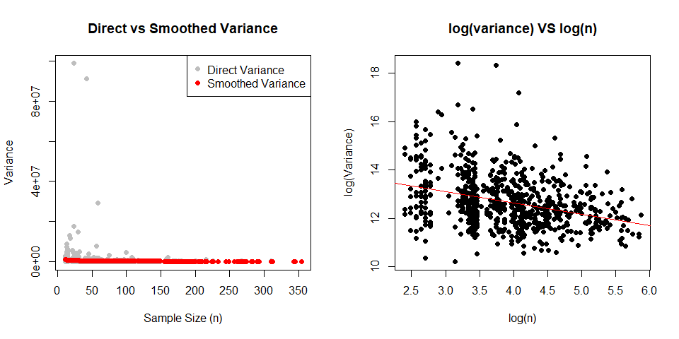

# 2.Import Auxiliary Variables

#### Import Auxiliary Data

Y = consumption expenditure per person  
X1 = Dependency  
X2 = nighttime light (NTL)  
X3 = Elevation  
X4 = Slope  
X5 = NDVI

Xi = …

```
##   adm2_pcode              y         vardir_smooth           se
##  Length:928         Min.   : 2517   Min.   : 216721   Min.   : 163.4
##  Class :character   1st Qu.: 5733   1st Qu.: 423700   1st Qu.: 388.0
##  Mode  :character   Median : 6893   Median : 549958   Median : 521.3
##                     Mean   : 7653   Mean   : 578268   Mean   : 685.3
##                     3rd Qu.: 8838   3rd Qu.: 695542   3rd Qu.: 750.7
##                     Max.   :20361   Max.   :1092791   Max.   :9931.4
##                     NA's   :190     NA's   :190       NA's   :190
##      vardir               n            log_ntl          dependency
##  Min.   :   26710   Min.   : 11.0   Min.   :0.02193   Min.   :31.52
##  1st Qu.:  150577   1st Qu.: 29.0   1st Qu.:0.39303   1st Qu.:39.12
##  Median :  271765   Median : 48.0   Median :0.59550   Median :41.01
##  Mean   :  928451   Mean   : 67.3   Mean   :0.90644   Mean   :41.73
##  3rd Qu.:  563593   3rd Qu.: 84.0   3rd Qu.:1.02169   3rd Qu.:43.47
##  Max.   :98632508   Max.   :354.0   Max.   :4.66996   Max.   :78.01
##  NA's   :190        NA's   :190
##     poptotal      elevation_mean       slope_mean         ndvi_mean
##  Min.   :  2737   Min.   :   2.545   Min.   : 0.04724   Min.   :0.1210
##  1st Qu.: 33359   1st Qu.:  42.958   1st Qu.: 0.44160   1st Qu.:0.5487
##  Median : 54127   Median : 146.595   Median : 1.28961   Median :0.6155
##  Mean   : 70918   Mean   : 187.679   Mean   : 3.18408   Mean   :0.6147
##  3rd Qu.: 86838   3rd Qu.: 232.113   3rd Qu.: 5.08365   3rd Qu.:0.7100
##  Max.   :541170   Max.   :1154.396   Max.   :16.18190   Max.   :0.8340
##
```

```
## [1] 190
```

| adm2_pcode | y | vardir_smooth | se | vardir | n | log_ntl | dependency | poptotal | elevation_mean | slope_mean | ndvi_mean |
| --- | --- | --- | --- | --- | --- | --- | --- | --- | --- | --- | --- |
| TH1001 | 15898.205 | 759674.0 | 4212.5322 | 17745427.47 | 24 | 4.66995949 | 56.83784 | 40254 | 7.616099 | 0.76633752 | 0.169 |
| TH1002 | 5172.092 | 684638.6 | 498.0937 | 248097.32 | 30 | 4.02173570 | 53.67184 | 75814 | 6.271512 | 0.34979747 | 0.243 |
| TH1003 | 9970.616 | 549957.7 | 904.9172 | 818875.07 | 48 | 1.92086404 | 35.43741 | 184138 | 3.770901 | 0.13257283 | 0.600 |
| TH1004 | NA | NA | NA | NA | NA | 4.18245898 | 77.69728 | 42921 | 10.507039 | 0.82956246 | 0.171 |
| TH1005 | 11145.749 | 406111.8 | 522.1072 | 272595.97 | 92 | 3.45727729 | 36.28451 | 184611 | 4.707692 | 0.15491113 | 0.397 |
| TH1006 | 14020.086 | 394328.1 | 916.8152 | 840550.07 | 98 | 3.69725319 | 38.79916 | 141360 | 4.512069 | 0.14654792 | 0.332 |
| TH1007 | 12443.364 | 605838.6 | 721.5531 | 520638.92 | 39 | 4.30035435 | 54.49289 | 40077 | 9.461048 | 0.84178771 | 0.272 |
| TH1008 | 18415.716 | 847057.0 | 3429.6709 | 11762642.65 | 19 | 4.47627290 | 64.66419 | 38100 | 9.677855 | 0.36180531 | 0.157 |
| TH1009 | 16055.818 | 507627.9 | 1026.0086 | 1052693.61 | 57 | 3.72044085 | 40.12689 | 85696 | 5.254184 | 0.19990202 | 0.277 |
| TH1010 | 16890.528 | 525136.9 | 1297.2618 | 1682888.26 | 53 | 3.06177037 | 37.22376 | 141018 | 3.722870 | 0.12356612 | 0.495 |

[output cut: 918 more lines]

#### Multicollinearity

Check Multi-Collinearity  
- plot Correlation Matrix r>0.8 high drop variable

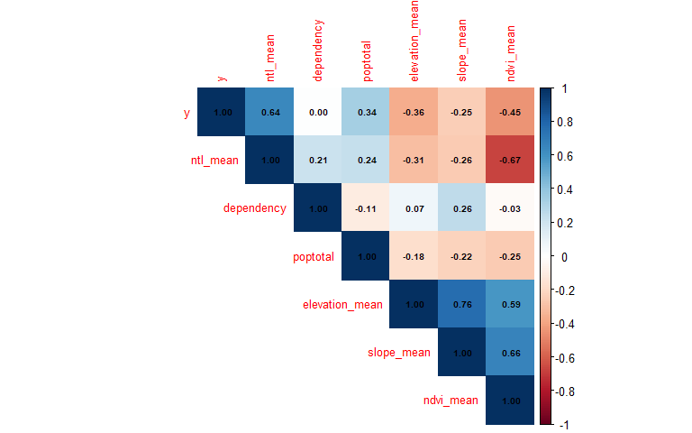

#### Variance Inflation Factor(VIF)

VIF for multicolinearity VIF = 1: No correlation at all V1 < VIF < 5: Some correlation, but acceptable (Normal level) 5 < VIF < 10: High correlation beginning (Caution advised) VIF > 10: Serious problem >>Edit by cut or composite variable or PCA Number of variable <= number area / 10

```
##       ntl_mean     dependency       poptotal elevation_mean     slope_mean
##       2.174490       1.234912       1.108022       2.537025       3.624915
##      ndvi_mean
##       3.483196
```

# 3.EBLUP FH Model

```r
mdata <- as.data.frame(mdata)

model_reml <- fh(
  fixed = y ~ dependency  + log_ntl +
    elevation_mean + slope_mean + ndvi_mean,
  vardir = "vardir_smooth", #  varinace direct estimate
  combined_data = mdata,
  domains = "adm2_pcode",
  method = "reml",        #  REML
  MSE = TRUE ,            #  Mean Squared Error
  transformation = "no", #
  mse_type= "analytical" )
```

```
## Please note that the model selection criteria are only computed based on the in-sample domains.
```

#### Coefficient Variable

```
## Call:
##  fh(fixed = y ~ dependency + log_ntl + elevation_mean + slope_mean +
##     ndvi_mean, vardir = "vardir_smooth", combined_data = mdata,
##     domains = "adm2_pcode", method = "reml", transformation = "no",
##     MSE = TRUE, mse_type = "analytical")
##
## Out-of-sample domains:  190
## In-sample domains:  738
##
## Variance and MSE estimation:
## Variance estimation method:  reml
## Estimated variance component(s):  2724649
## MSE method:  prasad-rao
##
## Coefficients:
##                coefficients  std.error t.value   p.value
## (Intercept)      6325.43232  919.29260  6.8808 5.953e-12 ***
## dependency        -68.07779   15.44102 -4.4089 1.039e-05 ***
## log_ntl          2546.96138  104.47632 24.3784 < 2.2e-16 ***
## elevation_mean     -1.70761    0.58052 -2.9415  0.003266 **
## slope_mean        115.38105   35.13307  3.2841  0.001023 **
## ndvi_mean        2605.78486  903.34312  2.8846  0.003919 **
## ---
## Signif. codes:  0 '***' 0.001 '**' 0.01 '*' 0.05 '.' 0.1 ' ' 1
##
## Explanatory measures:
##    loglike      AIC      BIC      KIC     AdjR2     FH_R2
## 1 -6589.59 13193.18 13225.41 13200.18 0.5748965 0.6184989
##
## Residual diagnostics:
##                        Skewness Kurtosis Shapiro_W    Shapiro_p
## Standardized_Residuals 1.505889 9.785618 0.8950025 4.989063e-22
## Random_effects         1.265849 8.227290 0.9228461 5.538345e-19
##
## Transformation: No transformation
```

#### Export FH Estimate

Random Effect (u_i)
$$std.res_i =
\frac{\hat{u}_i}{\sqrt{\widehat{Var}(\hat{u}_i)}}$$
for $u_i \sim N(0, \sigma_u^2)$

If Outliners -> Transformtion data (log or XGBoost)

```
## Please note that since all of the comparisons need a direct estimator, the plots are only created for in-sample domains.
```

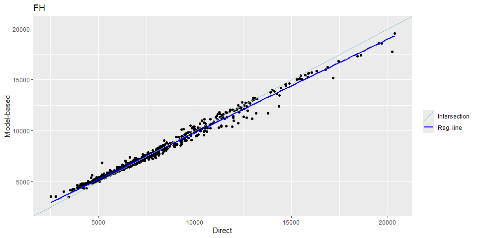

```
## Press [enter] to continue
```

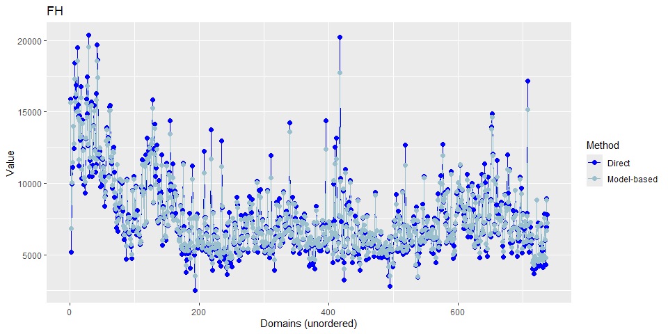

```r
compare_plot(model_reml) # in sample
```

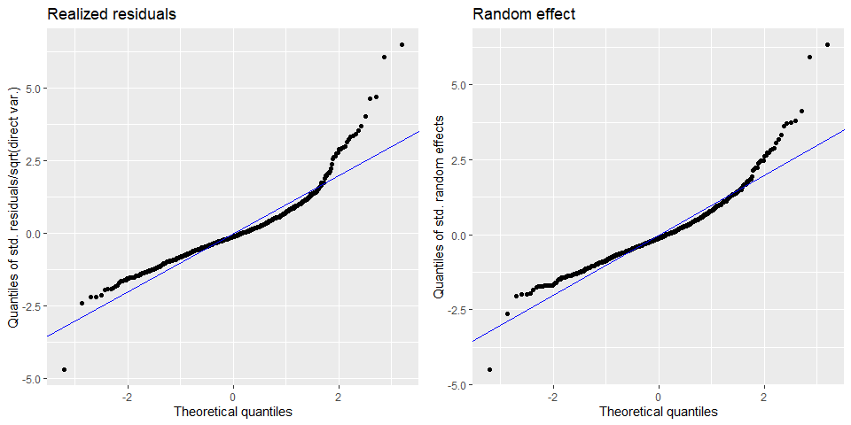

```
## Press [enter] to continue
```

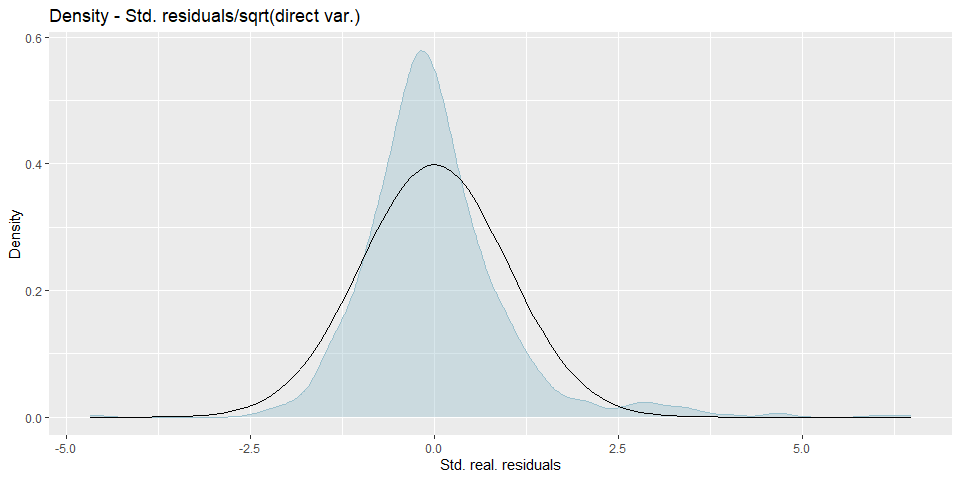

```
## Press [enter] to continue
```

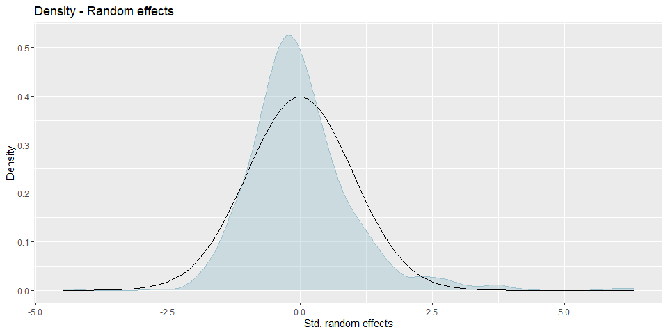

```r
plot(model_reml)
```

#### Gamma

**Shrinkage Factor (**$\gamma$) $\gamma_i = \frac{\sigma_u^2}{\sigma_u^2 + \psi_i}$

$\sigma_u^2$ = Variance of Random area effect $\psi_i$ = Sampling Variance

```r
#In sample
gamma_reml <- data.frame(
  Gamma   = model_reml$model$gamma$Gamma,
  Domain  = model_reml$model$gamma$Domain )
summary(gamma_reml)
```

```
##      Gamma           Domain
##  Min.   :0.7137   Length:928
##  1st Qu.:0.7966   Class :character
##  Median :0.8321   Mode  :character
##  Mean   :0.8280
##  3rd Qu.:0.8654
##  Max.   :0.9263
##  NA's   :190
```

```r
#write_xlsx(gamma_reml , "gamma_reml.xlsx")
```

#### Random effect & Residual & Fitted value

```r
# In-sample
ind_domains <- model_reml$ind$Domain[!is.na(model_reml$ind$Direct)]
diagnostics_reml <- data.frame(
  adm2_pcode         = ind_domains,
  Random_Effect      = model_reml$model$random_effects,
  Real_Residual      = model_reml$model$real_residuals,
  Std_Real_Residual  = model_reml$model$std_real_residuals,
  Fitted_Value       = model_reml$model$fitted )
summary(diagnostics_reml)
```

```
##   adm2_pcode        Random_Effect     Real_Residual      Std_Real_Residual
##  Length:738         Min.   :-6717.6   Min.   :-1687.96   Min.   :-2.040012
##  Class :character   1st Qu.: -904.8   1st Qu.: -179.00   1st Qu.:-0.245924
##  Mode  :character   Median : -179.6   Median :  -36.64   Median :-0.049699
##                     Mean   :    0.0   Mean   :    2.34   Mean   : 0.001052
##                     3rd Qu.:  674.6   3rd Qu.:  124.48   3rd Qu.: 0.173901
##                     Max.   : 9467.8   Max.   : 2469.80   Max.   : 2.833661
##   Fitted_Value
##  Min.   : 3643
##  1st Qu.: 6284
##  Median : 6802
##  Mean   : 7651
##  3rd Qu.: 8106
##  Max.   :14942
```

```r
#write_xlsx(diagnostics_reml , "diagnostics_reml.xlsx")
```

Direct estimate & FH estimate & MSE

```r
# All Area  928 Amphor/row
FH_reml <- data.frame(
  adm2_pcode = model_reml$ind$Domain,
  Direct = model_reml$ind$Direct,  #in-sample
  EBLUP = model_reml$ind$FH,  # All
  MSE_Direct = model_reml$MSE$Direct, #in-sample
  MSE_EBLUP = model_reml$MSE$FH)   # All
summary(FH_reml)
```

```
##   adm2_pcode            Direct          EBLUP         MSE_Direct
##  Length:928         Min.   : 2517   Min.   : 3475   Min.   : 216721
##  Class :character   1st Qu.: 5733   1st Qu.: 5907   1st Qu.: 423700
##  Mode  :character   Median : 6893   Median : 6693   Median : 549958
##                     Mean   : 7653   Mean   : 7442   Mean   : 578268
##                     3rd Qu.: 8838   3rd Qu.: 8153   3rd Qu.: 695542
##                     Max.   :20361   Max.   :19565   Max.   :1092791
##                     NA's   :190                     NA's   :190
##    MSE_EBLUP
##  Min.   : 200907
##  1st Qu.: 395721
##  Median : 535242
##  Mean   : 937736
##  3rd Qu.: 720933
##  Max.   :3044746
##
```

```r
#write_xlsx(FH_reml, "FH_REML.xlsx")
```

# 4. Precision and Effective

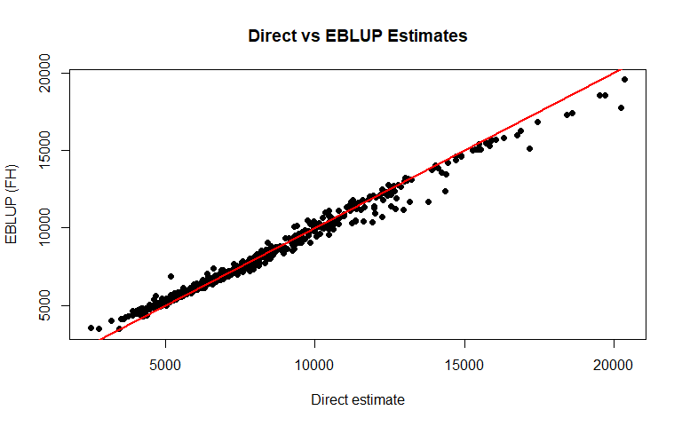

```
##   adm2_pcode            Direct          EBLUP         MSE_Direct
##  Length:738         Min.   : 2517   Min.   : 3475   Min.   : 216721
##  Class :character   1st Qu.: 5733   1st Qu.: 5890   1st Qu.: 423700
##  Mode  :character   Median : 6893   Median : 6873   Median : 549958
##                     Mean   : 7653   Mean   : 7651   Mean   : 578268
##                     3rd Qu.: 8838   3rd Qu.: 8671   3rd Qu.: 695542
##                     Max.   :20361   Max.   :19565   Max.   :1092791
##    MSE_EBLUP
##  Min.   :200907
##  1st Qu.:367492
##  Median :458496
##  Mean   :470093
##  3rd Qu.:555360
##  Max.   :783748
```

#### Coefficient of Variation (CV)

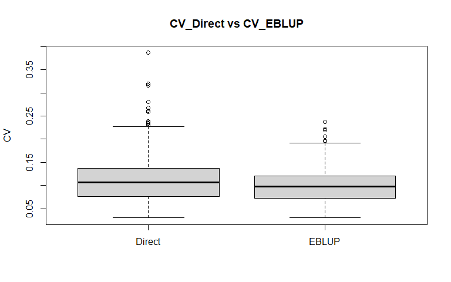

CV Reduction = CV_Direct - CV_EBLUP

```
## CV reduction% 11.43853
```

```
## CV reduction 0.01269967
```

```
## CV Direct 0.1110254
```

```
## CV EBLUP 0.0983257
```

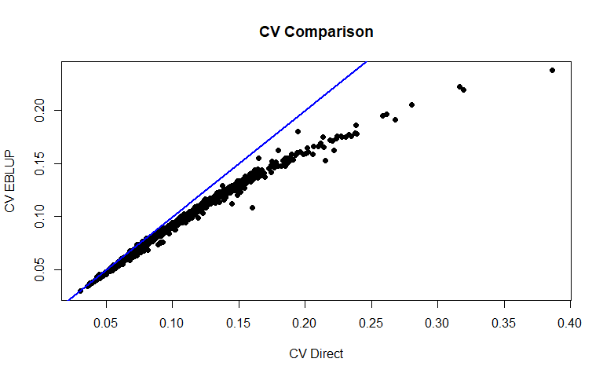

```r
plot(FH_compare$CV_Direct, FH_compare$CV_EBLUP,
    xlab="CV Direct",
    ylab="CV EBLUP",
    main="CV Comparison",
    pch=19)
abline(0,1,col="blue",lwd=2)
```

#### Mean Square Error (MSE)

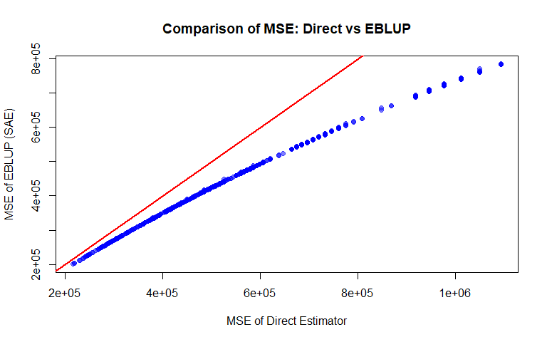

```
## MSE Direct 578267.8
```

```
## MSE EBLUP 470092.9
```

#### Residual

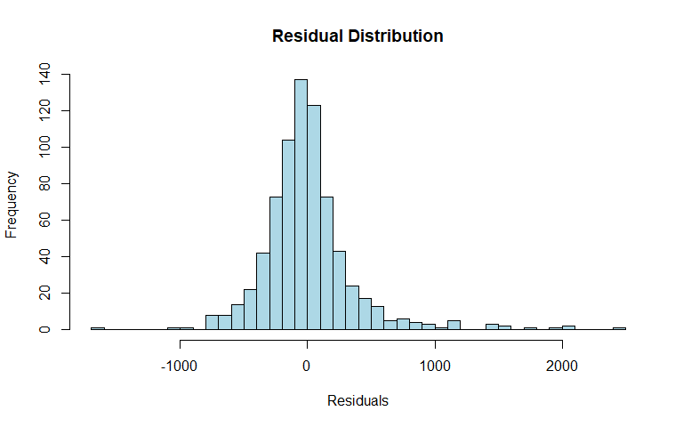

```r
hist(model_reml$model$real_residuals,
     main = "Residual Distribution",
     xlab = "Residuals",
     col = "lightblue",
     border = "black",
     breaks = 30)
```

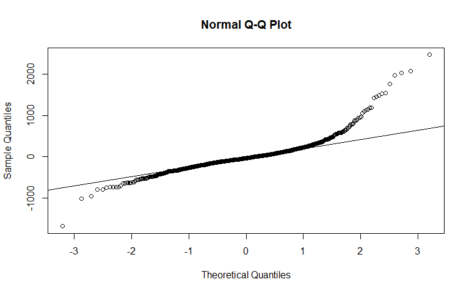

```r
qqnorm(model_reml$model$real_residuals)
qqline(model_reml$model$real_residuals)
```

#### Gamma & Shrinkage

Shrinkage size = EBLUP−Direct Gamma $\gamma_i$ (Shrinkage Factor)

```r
summary(model_reml$model$gamma$Gamma)
```

```
##    Min. 1st Qu.  Median    Mean 3rd Qu.    Max.    NA's
##  0.7137  0.7966  0.8321  0.8280  0.8654  0.9263     190
```

```r
model_reml$model$variance # estimated random effect variance
```

```
## [1] 2724649
```

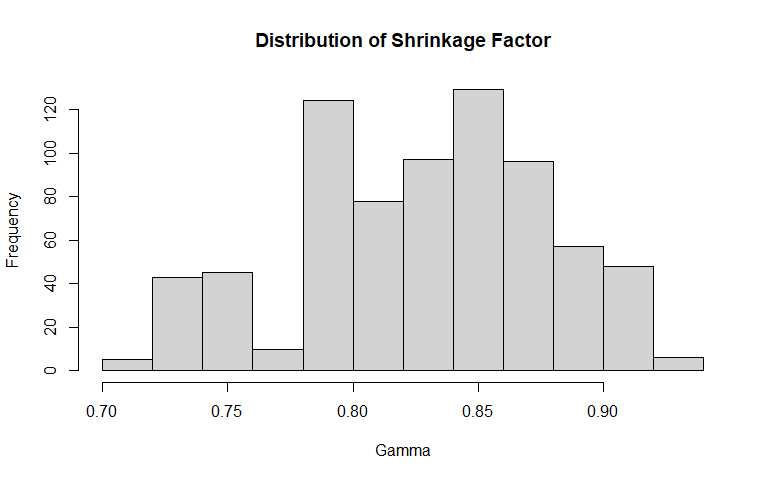

```r
hist(model_reml$model$gamma$Gamma,
     main="Distribution of Shrinkage Factor",
     xlab="Gamma")
```

```r
cat("Random effect",mean(model_reml$model$random_effects))
```

```
## Random effect -3.798445e-10
```

```r
cat("Variance Model",mean(model_reml$model$variance))
```

```
## Variance Model 2724649
```

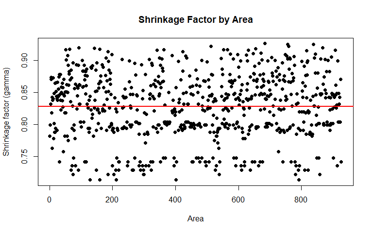

```r
plot(gamma_reml$Gamma,
    ylab="Shrinkage factor (gamma)",
    xlab="Area",
    main="Shrinkage Factor by Area",
    pch=19)
abline(h = mean(gamma_reml$Gamma, na.rm = TRUE), col = "red", lwd = 2)
```

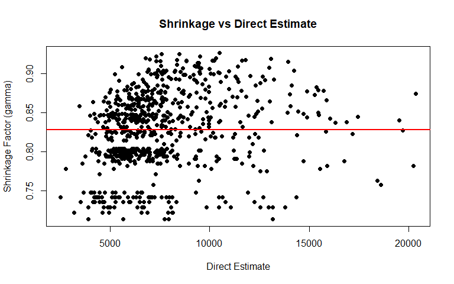

```r
plot(model_reml$ind$Direct,
     model_reml$model$gamma$Gamma,
     xlab="Direct Estimate",
     ylab="Shrinkage Factor (gamma)",
     main="Shrinkage vs Direct Estimate",
     pch=19)
abline(h = mean(gamma_reml$Gamma, na.rm = TRUE), col = "red", lwd = 2)
```